# r4ds_wrangle_exercises_16

Jessica Maldonado

October 18, 2017

## 16.2.4

**1. What happens if you parse a string that contains invalid dates?**

```r
ymd(c("2010-10-10", "bananas"))
```

```
## [1] "2010-10-10" NA
```

The first date parses, but you get a “failed to parse” message for “banana”.

**2. What does the tzone argument to today() do? Why is it important?**

It tells R which timezone you want today() to find the “today” date of. It will default to your computer’s time zone, so if you want “today” in China you have to set the specific time zone.

**3. Use the appropriate lubridate function to parse each of the following dates:**

```r
d1 <- "January 1, 2010"
d2 <- "2015-Mar-07"
d3 <- "06-Jun-2017"
d4 <- c("August 19 (2015)", "July 1 (2015)")
d5 <- "12/30/14" # Dec 30, 2014

mdy(d1)
```

```
## [1] "2010-01-01"
```

```r
ymd(d2)
```

```
## [1] "2015-03-07"
```

```r
dmy(d3)
```

```
## [1] "2017-06-06"
```

```r
mdy(d4)
```

```
## [1] "2015-08-19" "2015-07-01"
```

```r
mdy(d5)
```

```
## [1] "2014-12-30"
```

## 16.3.4

**1. How does the distribution of flight times within a day change over the course of the year?**

Overall the distribution is pretty similar, but there are more flights in the evening hours during the summre months when it’s lighter later compared to the winter months when it gets darker earlier.

```r
make_datetime_100 <- function(year, month, day, time) {
  make_datetime(year, month, day, time %/% 100, time %% 100)
}


flights_dt <- flights %>%
  filter(!is.na(dep_time), !is.na(arr_time)) %>%
  mutate(
    dep_time = make_datetime_100(year, month, day, dep_time),
    arr_time = make_datetime_100(year, month, day, arr_time),
    sched_dep_time = make_datetime_100(year, month, day, sched_dep_time),
    sched_arr_time = make_datetime_100(year, month, day, sched_arr_time)
  ) %>%
  select(origin, dest, ends_with("delay"), ends_with("time"))
```

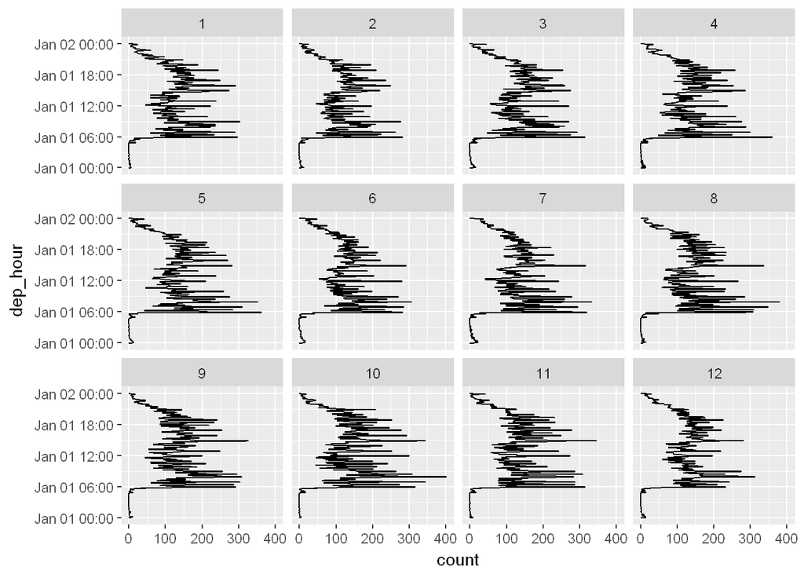

```r
flights_dt %>%
  mutate(dep_hour = update(dep_time, yday = 1), month = month(dep_time)) %>%
  ggplot(aes(dep_hour)) +
  geom_freqpoly(binwidth = 300) +
  facet_wrap(~month) +
  coord_flip()
```

**2. Compare dep_time, sched_dep_time and dep_delay. Are they consistent? Explain your findings.**

I can see below that there are 1205 flights that have a dep delay that doesn’t make up the difference between `dep_time` and `sched_dep_time`.

```r
flights_dt %>%
  select(dep_time, dep_delay, sched_dep_time) %>%
  mutate(dep_time2 = sched_dep_time + minutes(dep_delay), match = dep_time == dep_time2,
         math_diff = dep_time - sched_dep_time) %>%
  group_by(match) %>%
  count()
```

```
## # A tibble: 2 x 2
## # Groups:   match [2]
##   match      n
##   <lgl>  <int>
## 1 FALSE   1205
## 2  TRUE 326858
```

When I look at these matches specifically, I see that the flight difference puts the `dep_time` the day after the `sched_dep_time`, but for some reason the `dep_time` doesn’t actually change the date. So the hours roll over, but the date still stays the same, which means the dep_time is inaccurate.

```r
flights_dt %>%
  select(dep_time, dep_delay, sched_dep_time) %>%
  mutate(dep_time2 = sched_dep_time + minutes(dep_delay), match = dep_time == dep_time2,
         math_diff = dep_time - sched_dep_time) %>%
  filter(match == FALSE)
```

```
## # A tibble: 1,205 x 6
##               dep_time dep_delay      sched_dep_time           dep_time2
##                 <dttm>     <dbl>              <dttm>              <dttm>
##  1 2013-01-01 08:48:00       853 2013-01-01 18:35:00 2013-01-02 08:48:00
##  2 2013-01-02 00:42:00        43 2013-01-02 23:59:00 2013-01-03 00:42:00
##  3 2013-01-02 01:26:00       156 2013-01-02 22:50:00 2013-01-03 01:26:00
##  4 2013-01-03 00:32:00        33 2013-01-03 23:59:00 2013-01-04 00:32:00
##  5 2013-01-03 00:50:00       185 2013-01-03 21:45:00 2013-01-04 00:50:00
##  6 2013-01-03 02:35:00       156 2013-01-03 23:59:00 2013-01-04 02:35:00
##  7 2013-01-04 00:25:00        26 2013-01-04 23:59:00 2013-01-05 00:25:00
##  8 2013-01-04 01:06:00       141 2013-01-04 22:45:00 2013-01-05 01:06:00
##  9 2013-01-05 00:14:00        15 2013-01-05 23:59:00 2013-01-06 00:14:00
## 10 2013-01-05 00:37:00       127 2013-01-05 22:30:00 2013-01-06 00:37:00
## # ... with 1,195 more rows, and 2 more variables: match <lgl>,
## #   math_diff <time>
```

**3. Compare air_time with the duration between the departure and arrival. Explain your findings. (Hint: consider the location of the airport.)**

The vast majority of flights do not have an `air_time` that makes up the difference between `dep_time` and `arr_time`. A big part of this is time zones. Per documentation, the arr_times are in the local time zone, and the origin is always in the Eastern time zone. So for any flights going to a different time zone, there’s no way `arr_time` would match up. However, there are also a ton of flights to an east coast location like ORD that don’t have the times lining up. My hypothesis is that `dep_time` and `arr_time` are when the plane leaves and arrives at the gate, while air_time is actually time in the air. So things like taxiing, waiting in line, etc that can delay a plane from actually leaving righ after it leaves the gate could make up the difference.

```r
flights_dt %>%
  select(dep_time,  arr_time, air_time, origin, dest) %>%
  mutate(arr_time2 = dep_time + minutes(air_time), match = arr_time == arr_time2,
         diff_min = (arr_time2 - arr_time)/60) %>%
  group_by(match) %>%
  count()
```

```
## # A tibble: 3 x 2
## # Groups:   match [3]
##   match      n
##   <lgl>  <int>
## 1 FALSE 327150
## 2  TRUE    196
## 3    NA    717
```

**4. How does the average delay time change over the course of a day? Should you use dep_time or sched_dep_time? Why?**

Over the day, you can see the average delays steadily trending up. You want to use sched_dep_time, because using dep_time will show a huge spike in the hours between midnight - 5am, since the only flights leaving that early are delayed from the day before and will inherently have large delays.

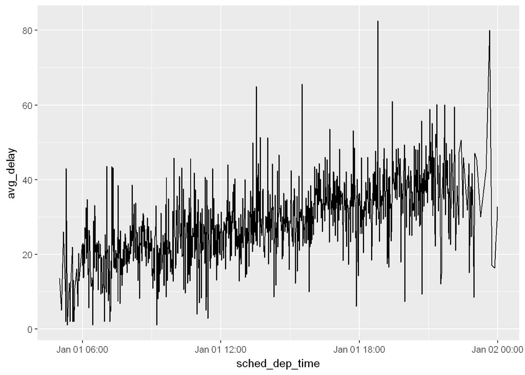

```r
flights_dt %>%
  filter(!is.na(dep_time), dep_delay > 0, dep_delay < 150) %>%
  mutate(dep_time = update(dep_time, yday = 1),
         sched_dep_time = update(sched_dep_time, yday = 1)) %>%
  group_by(sched_dep_time) %>%
  summarize(avg_delay = mean(dep_delay)) %>%
  ggplot(aes(sched_dep_time, avg_delay)) +
  geom_line()
```

**5. On what day of the week should you leave if you want to minimise the chance of a delay?**

Saturday has on average the lowest delays.

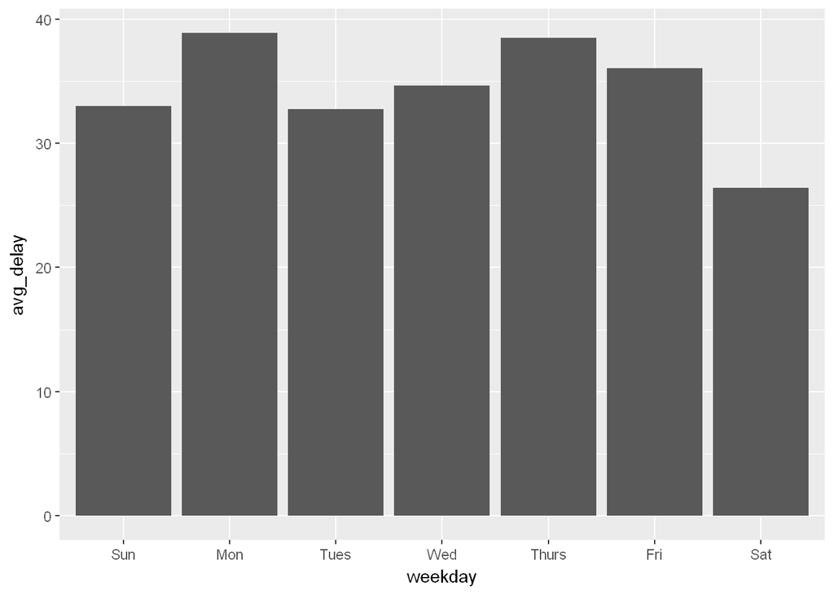

```r
flights_dt %>%
  filter(!is.na(dep_time), dep_delay >= 0) %>%
  mutate(weekday = wday(dep_time, label = TRUE)) %>%
  group_by(weekday) %>%
  summarize(avg_delay = mean(dep_delay)) %>%
  ggplot(aes(weekday, avg_delay)) +
  geom_col()
```

**6. What makes the distribution of `diamonds$carat` and `flights$sched_dep_time` similar?**

You see a distribution of spikes and dropoffs. With the diamond$carat distribution, the spikes are at and right after the carat (and .25, .5) mark, and the dropoffs are leading up to those spikes. With sched_dep_time, we know that people like to book flights at “nice times”, so those spikes are around the :15, :30, etc hour markings with the dips between those.

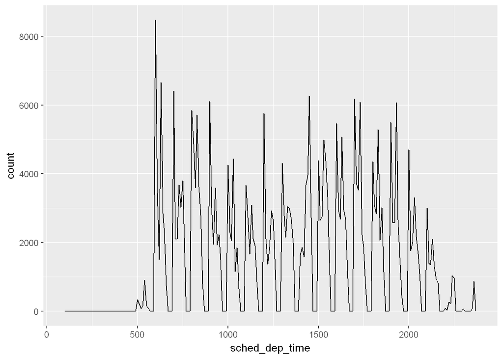

```r
flights %>%
  ggplot(aes(sched_dep_time)) +
  geom_freqpoly(binwidth = 10)
```

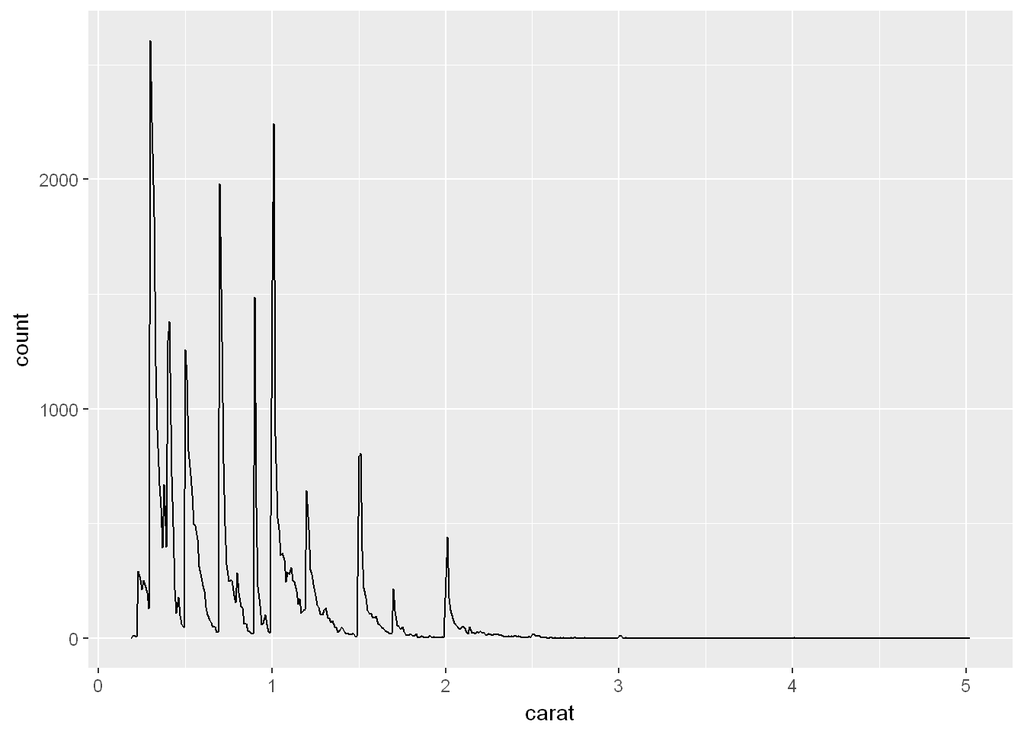

```r
diamonds %>%
  ggplot(aes(carat)) +
  geom_freqpoly(binwidth = .01)
```

**7. Confirm my hypothesis that the departures of flights in minutes 20-30 and 50-60 are caused by scheduled flights that leave early. Hint: create a binary variable that tells you whether or not a flight was delayed.**

The chart below clearly shows a spike in early (dep_delay < 0) flights in the 20 - 30 and 50 - 60 minute time frames.

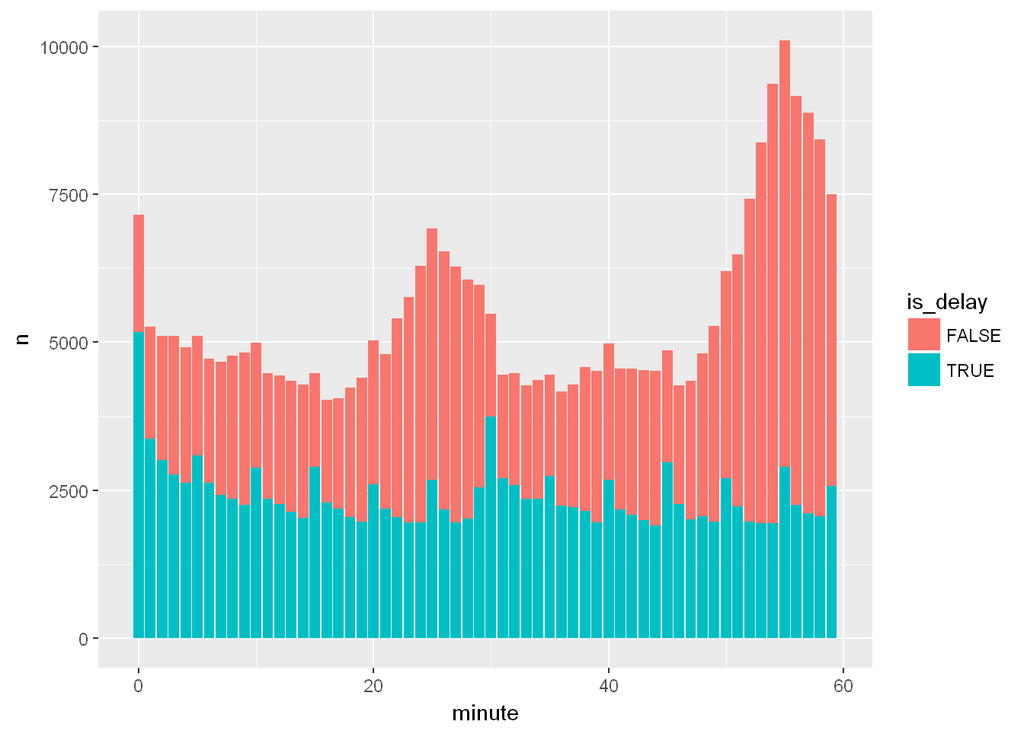

```r
flights_dt %>%
  mutate(minute = minute(dep_time), is_delay = dep_delay >= 0) %>%
  group_by(minute, is_delay) %>%
  count() %>%
  ggplot(aes(minute, n)) +
  geom_col(aes(fill = is_delay))
```

## 16.4.5

**1. Why is there months() but no dmonths()?**

There’s no standard duration of days in a month, like there are seconds in an hour, days in a week, etc. So there’s no way to give a decimal output that represents all months accurately.

**2. Explain days(overnight * 1) to someone who has just started learning R. How does it work?**

`overnight` is a variable that holds all the flights with an arrival time less than the departure time. We’ve identified these as overnight flights where the day of the departure flight was kept, but the arrival time is accurate. The days(1) period is used to add one day to the arrival date, keeping the same arrival time but ensuring that the date is accurate.

**3. Create a vector of dates giving the first day of every month in 2015. Create a vector of dates giving the first day of every month in the current year.**

```r
ymd("2015-01-01") + months(0:11)
```

```
##  [1] "2015-01-01" "2015-02-01" "2015-03-01" "2015-04-01" "2015-05-01"
##  [6] "2015-06-01" "2015-07-01" "2015-08-01" "2015-09-01" "2015-10-01"
## [11] "2015-11-01" "2015-12-01"
```

```r
ymd("201701-01") + months(0:11)
```

```
##  [1] "2017-01-01" "2017-02-01" "2017-03-01" "2017-04-01" "2017-05-01"
##  [6] "2017-06-01" "2017-07-01" "2017-08-01" "2017-09-01" "2017-10-01"
## [11] "2017-11-01" "2017-12-01"
```

**4. Write a function that given your birthday (as a date), returns how old you are in years.**

```r
("1993-09-22" %--% today()) / years()
```

```
## [1] 24.08219
```

**5. Why can’t (today() %–% (today() + years(1)) / months(1) work?**

There’s a missing parenthesis after years(1)). If you add it in, you get 12.

```r
(today() %--% (today() + years(1))) / months(1)
```

```
## [1] 12
```